# 2.5 Practical: categorical predictor

Benjamin Rosenbaum

October 20, 2020

In this exercise, we will learn different ways to code a categorical predictor. We will also learn how to use the `generated quantities{}` block.

Suppose we have measurements of a continuous variable in 2 groups, e.g. individual body masses in 2 populations.

We want to test if both groups have a different mean.

statistical model:
$$\begin{aligned}
y_{1,i} & \sim \text{normal}(\mu_1, \sigma),\quad i=1,...,n_1 \\
y_{2,i} & \sim \text{normal}(\mu_2, \sigma),\quad i=1,...,n_2
\end{aligned}$$

Notice that here, we assume that both populations have the same standard deviation.

We could also model 2 separate standard deviations.

Research question: what is the mean difference $\delta=\mu_2-\mu_1$ of both populations?

# Setup

```r
rm(list=ls())
library(rstan)
library(coda)
```

```r
library(BayesianTools)
setwd("~/Nextcloud/teaching Bayes")

rstan_options(auto_write = TRUE)
options(mc.cores = 3) # number of CPU cores
```

# Generate data

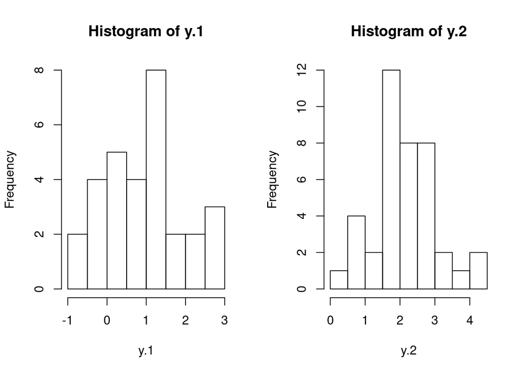

```r
set.seed(123) # initiate random number generator for reproducibility

n.1 = 30
mu.1 = 1
sigma.1 = 1

n.2 = 40
mu.2 = 2
sigma.2 = 1

y.1 = rnorm(n=n.1, mean=mu.1, sd=sigma.1)
y.2 = rnorm(n=n.2, mean=mu.2, sd=sigma.2)

par(mfrow=c(1,2))
hist(y.1)
hist(y.2)
```

# Stan code

We translate the statistical model above straightforward into a Stan model.

```r
stan_code = '
data {
  int n1;
  vector[n1] y1;
  int n2;
  vector[n2] y2;
}
parameters {
  real mu1;
  real mu2;
  real<lower=0> sigma;
}
model {
  // priors
  mu1 ~ normal(0, 10);
  mu2 ~ normal(0, 10);
  sigma ~ normal(0, 10);
  // likelihood
  y1 ~ normal(mu1, sigma);
  y2 ~ normal(mu2, sigma);
}
'
```

# Data and sampler preparation, MCMC sampling

```r
data = list(n1=n.1,
            n2=n.2,
            y1=y.1,
            y2=y.2)

stan_model = stan_model(model_code=stan_code)
# save(stan_model, file="stan_model.Rdata")
# load("stan_model.Rdata")

fit  = sampling(stan_model,
                data=data,
                chains=3,
                iter=2000,
                warmup=1000
)
```

# Check convergence and posterior

Model convergence diagnostics look OK!

```r
print(fit, digits=3, probs=c(0.025, 0.975))
```

```
## Inference for Stan model: 0ab162938244b349807ac9539ddc164c.
## 3 chains, each with iter=2000; warmup=1000; thin=1;
## post-warmup draws per chain=1000, total post-warmup draws=3000.
##
##          mean se_mean    sd    2.5%   97.5% n_eff  Rhat
## mu1     0.953   0.003 0.165   0.621   1.287  2647 1.000
## mu2     2.164   0.003 0.145   1.882   2.452  2621 1.001
## sigma   0.924   0.002 0.079   0.786   1.096  2632 1.000
## lp__  -28.826   0.031 1.179 -31.919 -27.465  1441 1.002
##
## Samples were drawn using NUTS(diag_e) at Wed Oct 14 10:40:43 2020.
## For each parameter, n_eff is a crude measure of effective sample size,
## and Rhat is the potential scale reduction factor on split chains (at
## convergence, Rhat=1).
```

```
## ci_level: 0.8 (80% intervals)
```

```
## outer_level: 0.95 (95% intervals)
```

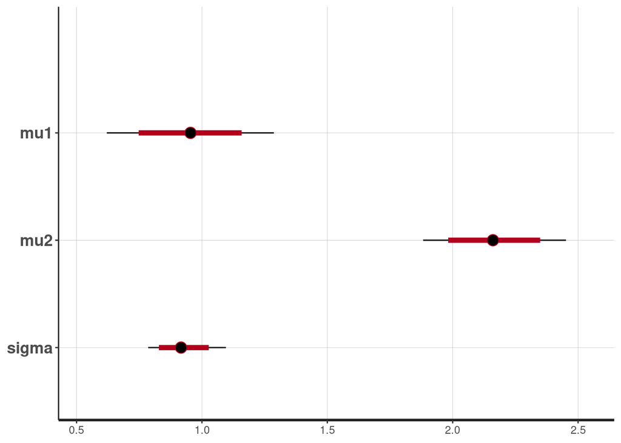

```r
plot(fit)
```

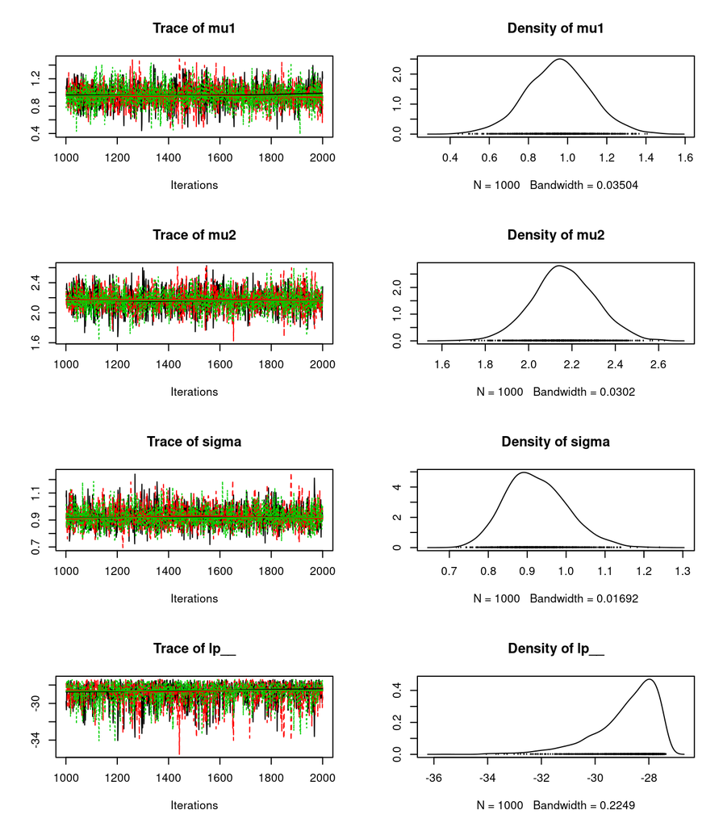

```r
plot(As.mcmc.list(fit)) # from coda package
```

To answer our research questions, we look at the posterior distribution of $\delta=\mu_2-\mu_1$.

First, we convert the posterior into a matrix. Each row represents a sample from the posterior distribution.

```r
posterior=as.matrix(fit)

str(posterior)
```

```
##  num [1:3000, 1:4] 1.06 1.09 1.04 1.2 1.21 ...
##  - attr(*, "dimnames")=List of 2
##   ..$ iterations: NULL
##   ..$ parameters: chr [1:4] "mu1" "mu2" "sigma" "lp__"
```

```r
head(posterior)
```

```
##           parameters
## iterations      mu1      mu2     sigma      lp__
##       [1,] 1.055969 2.319219 1.0727413 -29.79091
##       [2,] 1.092548 2.311230 1.1161136 -30.69647
##       [3,] 1.036003 2.388757 0.9598740 -28.83383
##       [4,] 1.197231 2.320138 0.9703966 -29.19172
##       [5,] 1.207358 2.302728 0.8976184 -29.04750
##       [6,] 1.039844 2.113061 0.9292394 -27.61672
```

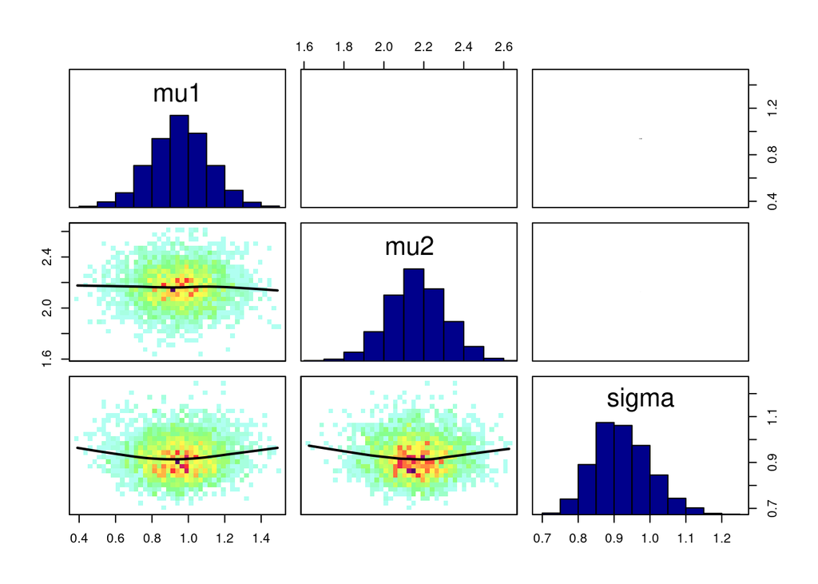

```r
correlationPlot(posterior[, 1:3], thin=1)
```

Now we compute the distribution of differences.

We compute the posterior probability of $\delta$ being postitive given the data $P(\delta>0|y)$:

We count the number the event occurs and divide by the number of samples.

Given the data, we are 100% sure that $\delta>0$, i.e. $\mu_1 < \mu_2$

```r
delta = posterior[, "mu2"] - posterior[, "mu1"]

mean(delta)
```

```
## [1] 1.21089
```

```r
sd(delta)
```

```
## [1] 0.2191148
```

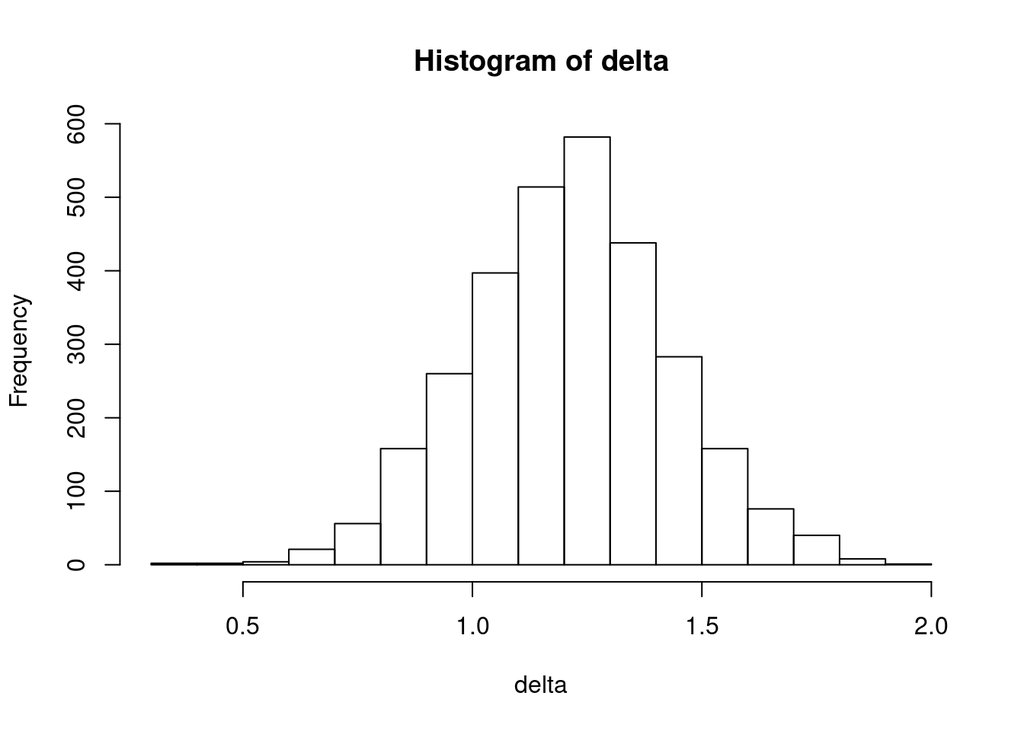

```r
hist(delta)
abline(v=0, col="red", lwd=2)
```

```r
sum(delta>0)/nrow(posterior)
```

```
## [1] 1
```

# Alternative coding using `generated quantities{}`

Instead of computing delta after fitting, we can include it in the model.

```r
stan_code_delta = '
data {
  int n1;
  vector[n1] y1;
  int n2;
  vector[n2] y2;
}
parameters {
  real mu1;
  real mu2;
  real<lower=0> sigma;
}
model {
  // priors
  mu1 ~ normal(0, 10);
  mu2 ~ normal(0, 10);
  sigma ~ normal(0, 10);
  // likelihood
  y1 ~ normal(mu1, sigma);
  y2 ~ normal(mu2, sigma);
}
generated quantities{
  real delta;
  delta = mu2-mu1;
}
'

stan_model_delta = stan_model(model_code=stan_code_delta)
# save(stan_model_delta, file="stan_model_delta.Rdata")
# load("stan_model_delta.Rdata")

fit_delta  = sampling(stan_model_delta,
                      data=data,
                      chains=3,
                      iter=2000,
                      warmup=1000
)
```

Now we can directly look at delta:

```r
print(fit_delta, digits=3, probs=c(0.025, 0.975))
```

```
## Inference for Stan model: 3a72ff20b32726c98447e6da8adabe2a.
## 3 chains, each with iter=2000; warmup=1000; thin=1;
## post-warmup draws per chain=1000, total post-warmup draws=3000.
##
##          mean se_mean    sd    2.5%   97.5% n_eff  Rhat
## mu1     0.953   0.003 0.175   0.610   1.285  2842 1.000
## mu2     2.164   0.003 0.148   1.878   2.459  2823 1.000
## sigma   0.925   0.002 0.082   0.780   1.102  2727 0.999
## delta   1.212   0.004 0.231   0.768   1.655  2835 0.999
## lp__  -28.946   0.034 1.259 -32.320 -27.472  1354 1.001
##
## Samples were drawn using NUTS(diag_e) at Wed Oct 14 10:41:18 2020.
## For each parameter, n_eff is a crude measure of effective sample size,
## and Rhat is the potential scale reduction factor on split chains (at
## convergence, Rhat=1).
```

```
## ci_level: 0.8 (80% intervals)
```

```
## outer_level: 0.95 (95% intervals)
```

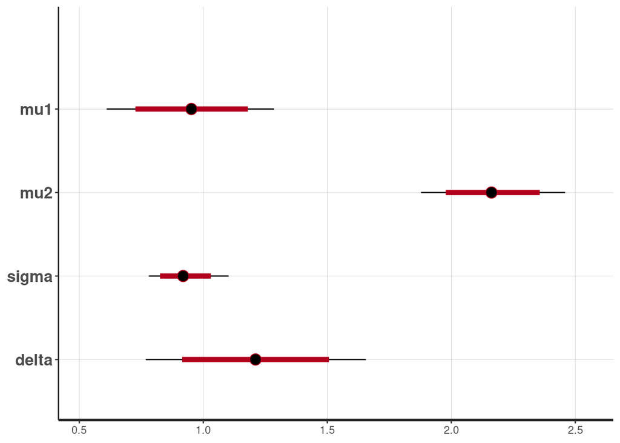

```r
plot(fit_delta)
```

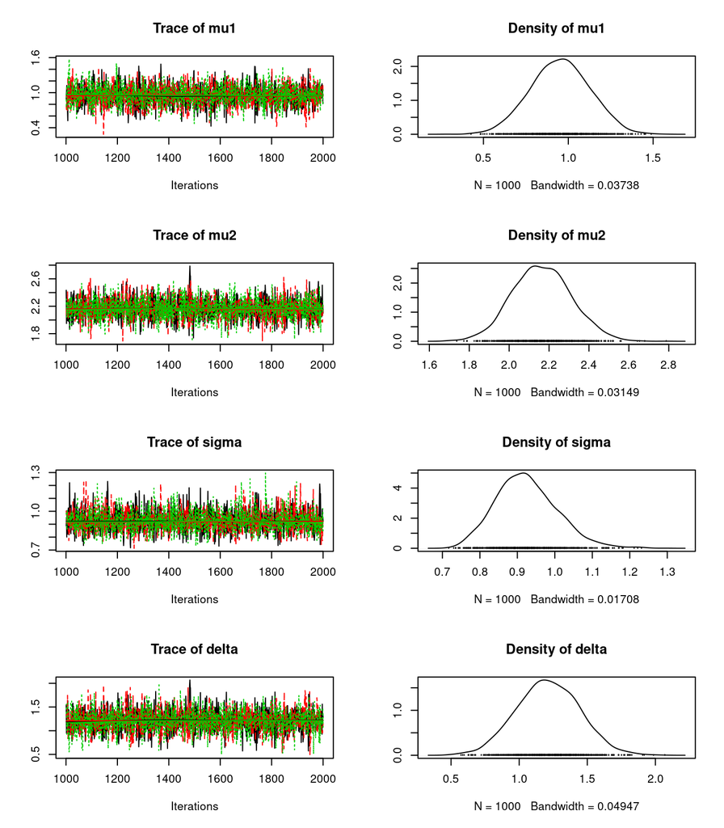

```r
plot(As.mcmc.list(fit_delta)[, 1:4]) # from coda package
```

# Classical data format with categorical predictor

Here we code the data differently, just one dataset with a factorial predictor `group`.

```r
df = data.frame(y=c(y.1,y.2), group=c(rep(1,n.1),rep(2,n.2)))

head(df)
```

```
##           y group
## 1 0.4395244     1
## 2 0.7698225     1
## 3 2.5587083     1
## 4 1.0705084     1
## 5 1.1292877     1
## 6 2.7150650     1
```

```r
data = list(y=df$y,
            group=df$group,
            n=nrow(df))
```

Note that the factorial group is an integer (1 or 2), so we can use it as an index in the Stan model.

The statistical model reads:
$$y_i \sim~ \text{normal}(\mu_{group_i}, \sigma),\quad i=1,\dots,n$$

$\mu$ now is a vector of length 2.

```r
stan_code_alternative = '
data {
  int n;
  real y[n];
  int group[n];
}
parameters {
  real mu[2];
  real<lower=0> sigma;
}
model {
  // priors
  mu ~ normal(0, 10);
  sigma ~ normal(0, 10);
  // likelihood
  for(i in 1:n){
    y[i] ~ normal(mu[group[i]], sigma);
  }
}
generated quantities{
  real delta;
  delta = mu[2]-mu[1];
}
'

stan_model_alternative = stan_model(model_code=stan_code_alternative)
# save(stan_model_alternative, file="stan_model_alternative.Rdata")
# load("stan_model_alternative.Rdata")

fit_alternative  = sampling(stan_model_alternative,
                            data=data,
                            chains=3,
                            iter=2000,
                            warmup=1000
)
```

```r
print(fit_alternative, digits=3, probs=c(0.025, 0.975))
```

```
## Inference for Stan model: cad9e0a079f44892ef1151950047160b.
## 3 chains, each with iter=2000; warmup=1000; thin=1;
## post-warmup draws per chain=1000, total post-warmup draws=3000.
##
##          mean se_mean    sd    2.5%   97.5% n_eff  Rhat
## mu[1]   0.955   0.003 0.171   0.623   1.301  3112 1.001
## mu[2]   2.165   0.003 0.148   1.874   2.454  3338 1.000
## sigma   0.926   0.002 0.082   0.787   1.105  2631 1.001
## delta   1.209   0.004 0.224   0.769   1.658  3385 1.000
## lp__  -28.922   0.033 1.301 -32.332 -27.477  1523 1.002
##
## Samples were drawn using NUTS(diag_e) at Wed Oct 14 10:41:54 2020.
## For each parameter, n_eff is a crude measure of effective sample size,
## and Rhat is the potential scale reduction factor on split chains (at
## convergence, Rhat=1).
```

# Classical data format and dummy coding

Again, we code the data a little differently. Same as above, but `group=0` for population 1 and `group=1` for population 2.

This is known as **dummy coding** and the statistical model reads
$$y_i \sim \text{normal}(\mu + \delta\cdot group_i, \sigma)$$

Here, $\mu$ is a single value and decribes the mean of population 1: $\mu+0\cdot\delta$ (`group=0`),

$\delta$ is the “effect” of population 2 compared to population 1, the mean of population 2 is: $\mu+1\cdot\delta$ (`group=1`)

```r
df = data.frame(y=c(y.1,y.2), group=c(rep(0,n.1),rep(1,n.2))) # now group1=0, group2=1

head(df)
```

```
##           y group
## 1 0.4395244     0
## 2 0.7698225     0
## 3 2.5587083     0
## 4 1.0705084     0
## 5 1.1292877     0
## 6 2.7150650     0
```

```r
data = list(y=df$y,
            group=df$group,
            n=nrow(df))

stan_code_alternative_2 = '
data {
  int n;
  real y[n];
  int group[n];
}
parameters {
  real mu;
  real delta;
  real<lower=0> sigma;
}
model {
  // priors
  mu ~ normal(0, 10);
  delta ~ normal(0, 10);
  sigma ~ normal(0, 10);
  // likelihood
  for(i in 1:n){
    y[i] ~ normal(mu + group[i]*delta, sigma);
  }
}
'
```

```r
stan_model_alternative_2 = stan_model(model_code=stan_code_alternative_2)
# save(stan_model_alternative_2, file="stan_model_alternative_2.Rdata")
# load("stan_model_alternative_2.Rdata")

fit_alternative_2  = sampling(stan_model_alternative_2,
                              data=data,
                              chains=3,
                              iter=2000,
                              warmup=1000
)
```

```r
print(fit_alternative_2, digits=3, probs=c(0.025, 0.975))
```

```
## Inference for Stan model: bcbaccca31c7141872306dd004771f7a.
## 3 chains, each with iter=2000; warmup=1000; thin=1;
## post-warmup draws per chain=1000, total post-warmup draws=3000.
##
##          mean se_mean    sd    2.5%   97.5% n_eff  Rhat
## mu      0.952   0.004 0.165   0.623   1.277  1457 1.002
## delta   1.213   0.006 0.215   0.788   1.638  1348 1.001
## sigma   0.928   0.002 0.082   0.787   1.111  1596 1.000
## lp__  -28.852   0.034 1.229 -32.008 -27.460  1292 1.002
##
## Samples were drawn using NUTS(diag_e) at Wed Oct 14 10:42:27 2020.
## For each parameter, n_eff is a crude measure of effective sample size,
## and Rhat is the potential scale reduction factor on split chains (at
## convergence, Rhat=1).
```

# Frequentist solutions

```r
t.test(y.1, y.2)
```

```
##
##  Welch Two Sample t-test
##
## data:  y.1 and y.2
## t = -5.4121, df = 57.308, p-value = 1.275e-06
## alternative hypothesis: true difference in means is not equal to 0
## 95 percent confidence interval:
##  -1.6598746 -0.7633823
## sample estimates:
## mean of x mean of y
## 0.9528962 2.1645247
```

```r
df$group = as.factor(df$group)
summary(lm(y~group, data=df))
```

```
##
## Call:
## lm(formula = y ~ group, data = df)
##
## Residuals:
##     Min      1Q  Median      3Q     Max
## -1.9195 -0.5618 -0.0761  0.5397  2.0044
##
## Coefficients:
##             Estimate Std. Error t value Pr(>|t|)
## (Intercept)   0.9529     0.1658   5.749 2.32e-07 ***
## group1        1.2116     0.2193   5.526 5.61e-07 ***
## ---
## Signif. codes:  0 '***' 0.001 '**' 0.01 '*' 0.05 '.' 0.1 ' ' 1
##
## Residual standard error: 0.9079 on 68 degrees of freedom
## Multiple R-squared:  0.3099, Adjusted R-squared:  0.2997
## F-statistic: 30.53 on 1 and 68 DF,  p-value: 5.615e-07
```

Common statistical tests are linear models!

https://lindeloev.github.io/tests-as-linear/